# Lasso and Elastic-Net Regularized Generalized Linear Models

Logistic Regression Model

# 1 Prepare data/matrices

```r
#read the data that is stored under the data folder

scrambled<-readRDS(file = "./Data/scrambled.rds")

scrambled <- scrambled  %>% mutate(log10_B_HBA1C_PRC=log10(B_HBA1C_PRC),log10_DU_ACR=log10(DU_ACR))

#select variables for unadjusted model
data <- scrambled  %>% select("KIM1.npx","SYND1.npx","IL.1RT1.npx","WFDC2.npx","CD27.npx", "TNFRSF10A.npx","LAYN.npx","PVRL4.npx","EDA2R.npx","TNFRSF4.npx","GFR_alpha_1_npx","TNF.R1.npx","PI3_npx", "EFNA4.npx","TNF.R2.npx" ,"DLL1.npx" ,"TNFRSF6B.npx", "CD160.npx","EPHA2.npx","RELT.npx","LTBR.npx","time","status")

#drop any records with NA
data_drop_na <- data %>% drop_na()

#Total sample size
nrow(data_drop_na)
```

```
#> [1] 374
```

```r
#includes all proteins after excluding missing data
x <- data.matrix(data_drop_na[,c("KIM1.npx","SYND1.npx","IL.1RT1.npx","WFDC2.npx","CD27.npx", "TNFRSF10A.npx","LAYN.npx","PVRL4.npx","EDA2R.npx","TNFRSF4.npx","GFR_alpha_1_npx","TNF.R1.npx","PI3_npx", "EFNA4.npx","TNF.R2.npx" ,"DLL1.npx" ,"TNFRSF6B.npx", "CD160.npx","EPHA2.npx","RELT.npx","LTBR.npx")])

#select follow-up time and status
y <- data.matrix(data_drop_na[,c("status")])
```

# 2 glmnet for a given $\alpha$

## 2.1 Fit logistic regression glmnet for a given $\alpha$

- Mixing (hyper) parameter $\alpha$ by default is equal to $1$ (lasso regression)

```r
#fit the unadjusted(???) logistic regression model
pfit <- glmnet(x, y, family = "binomial")
```

## 2.2 Unadjusted Logistic Regression Model Coefficient Plot

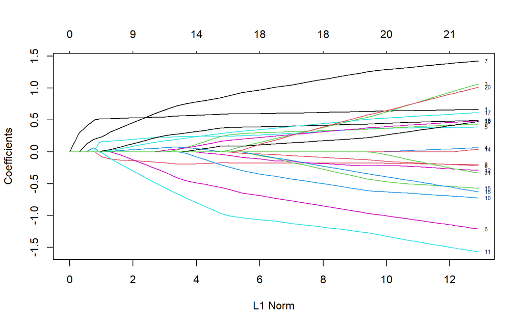

```r
plot(pfit, label = TRUE)
```

“Each curve corresponds to a variable. It shows the path of its coefficient against the ${\ell}_1$-norm of the whole coefficient vector as $\lambda$ varies. The axis above indicates the number of nonzero coefficients at the current $\lambda$, which is the effective degrees of freedom (df) for the lasso.”

source: (“https://glmnet.stanford.edu/articles/glmnet.html”)

# 3 glmnetUtils Glmnet models for multiple alpha

- We use cross-validation to select a value for $\alpha$.
- The idea of “explicitly control the fold” is implemented in `glmnetUtils` package

source: (https://glmnet.stanford.edu/articles/glmnet.html)

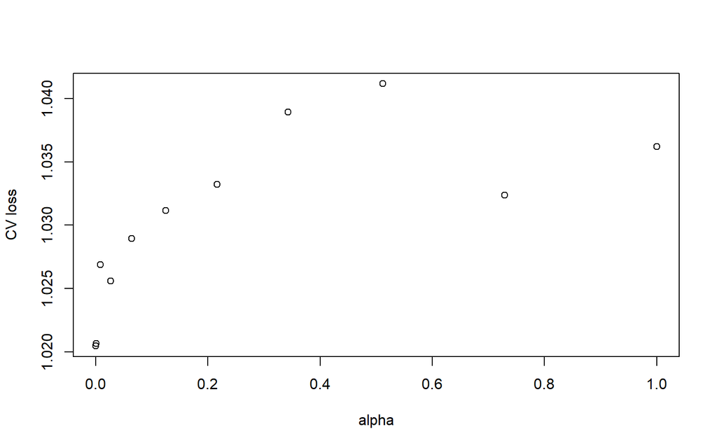

```r
set.seed(46)
alphv <- seq(0, 1, len = 11)^3
cva_pfit <- cva.glmnet(x=x,y=y,family = "binomial", alpha = alphv)
minlossplot(cva_pfit)
```

Extract the best parameters from cva.glmnet object

```r
# Extract the best parameters from cva.glmnet object.
get_model_params <- function(fit) {
  alpha <- fit$alpha
  lambdaMin <- sapply(fit$modlist, `[[`, "lambda.min")
  lambdaSE <- sapply(fit$modlist, `[[`, "lambda.1se")
  error <- sapply(fit$modlist, function(mod) {min(mod$cvm)})
  best <- which.min(error)
  data.frame(alpha = alpha[best], lambdaMin = lambdaMin[best],
             lambdaSE = lambdaSE[best], eror = error[best])
}

get_model_params(cva_pfit)
```

[output not shown]

Logistic regression coefficients using the best parameters

```r
coef(cva_pfit, s = get_model_params(cva_pfit)$lambdaMin, alpha=get_model_params(cva_pfit)$alpha)
```

```
#> 22 x 1 sparse Matrix of class "dgCMatrix"
#>                          s1
#> (Intercept)     -6.33773093
#> KIM1.npx         0.53578744
#> SYND1.npx       -0.23045636
#> IL.1RT1.npx      0.13906491
#> WFDC2.npx        0.14465465
#> CD27.npx         0.29901801
#> TNFRSF10A.npx   -0.51869066
#> LAYN.npx         0.67463380
#> PVRL4.npx       -0.02727495
#> EDA2R.npx        0.24223464
#> TNFRSF4.npx     -0.20585037
#> GFR_alpha_1_npx -0.77629061
#> TNF.R1.npx      -0.18587140
#> PI3_npx          0.36329280
#> EFNA4.npx        0.11395665
#> TNF.R2.npx      -0.15156646
#> DLL1.npx        -0.23743619
#> TNFRSF6B.npx     0.29407479
#> CD160.npx        0.23646593
#> EPHA2.npx        0.09114926
#> RELT.npx         0.21597976
#> LTBR.npx        -0.02697714
```

Save cva.object for post-processing

```r
save(cva_pfit, file = "./save/21Logistic-Reg1-save1.Rdata")
```

# 4 Cross-validation of logistic regression model (Optional)

## 4.1 Unadjusted Logistic Regression Model

## 4.2 - coefficient plot

### 4.2.1 Unadjusted Cross-Validated Logistic Regression Model Coefficient Plot

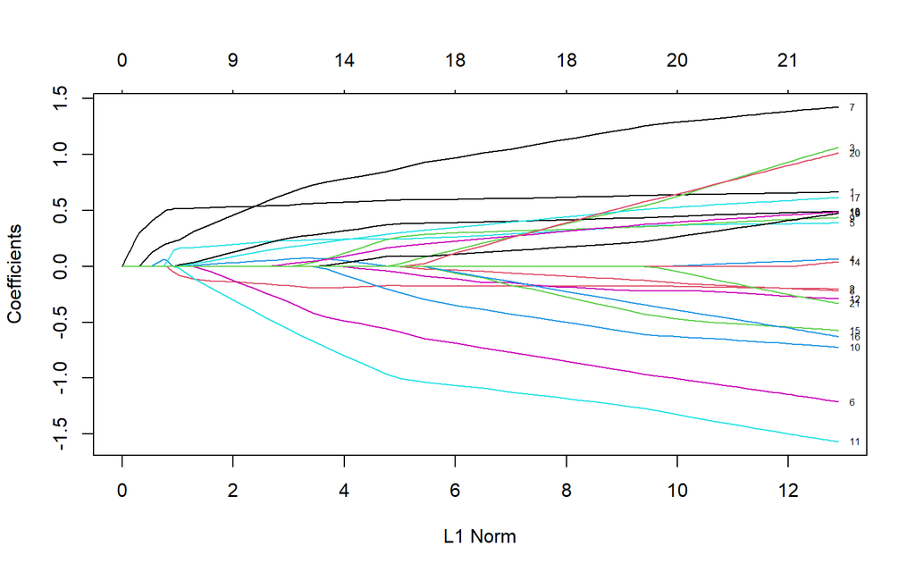

```r
#fit the cross-validatedmodel
cvfit <- cv.glmnet(x, y, family = "binomial")

plot(pfit, label = TRUE)
```

source: (“https://glmnet.stanford.edu/articles/glmnet.html”)

## 4.3 - minimal lambda value

### 4.3.1 Unadjusted Cross-Validated Logistic Regression Coefficients using the minimal lambda value

```r
#get the minimal lambda value (value of lambda that gives minimum cvm)
cvfit$lambda.min
```

```
#> [1] 0.004753842
```

```r
# Cross-validated logistic regression Model using the minimal lambda
coef(cvfit, s = "lambda.min")
```

```
#> 22 x 1 sparse Matrix of class "dgCMatrix"
#>                           s1
#> (Intercept)     -7.132368436
#> KIM1.npx         0.575365537
#> SYND1.npx       -0.190011319
#> IL.1RT1.npx      .
#> WFDC2.npx        0.050554181
#> CD27.npx         0.242140825
#> TNFRSF10A.npx   -0.484679850
#> LAYN.npx         0.781028135
#> PVRL4.npx        .
#> EDA2R.npx        0.113984837
#> TNFRSF4.npx     -0.075972750
#> GFR_alpha_1_npx -0.794311083
#> TNF.R1.npx      -0.003629924
#> PI3_npx          0.316742155
#> EFNA4.npx        .
#> TNF.R2.npx       .
#> DLL1.npx         .
#> TNFRSF6B.npx     0.236249245
#> CD160.npx        0.087360595
#> EPHA2.npx        0.030920241
#> RELT.npx         .
#> LTBR.npx         .
```

## 4.4 - lambda.lse

#### 4.4.0.1 Unadjusted Cross-Validated Logistic Regression Coefficients using lambda.lse

```r
#largest value of lambda such that error is within 1 standard error of the minimum.
cvfit$lambda.lse
```

[output not shown]

```r
# Cross-validated Logistic Regression Model using the lambda.lse
coef(cvfit)
```

```
#> 22 x 1 sparse Matrix of class "dgCMatrix"
#>                         s1
#> (Intercept)     -3.5755585
#> KIM1.npx         0.3523050
#> SYND1.npx        .
#> IL.1RT1.npx      .
#> WFDC2.npx        .
#> CD27.npx         .
#> TNFRSF10A.npx    .
#> LAYN.npx         0.0610158
#> PVRL4.npx        .
#> EDA2R.npx        .
#> TNFRSF4.npx      .
#> GFR_alpha_1_npx  .
#> TNF.R1.npx       .
#> PI3_npx          .
#> EFNA4.npx        .
#> TNF.R2.npx       .
#> DLL1.npx         .
#> TNFRSF6B.npx     .
#> CD160.npx        .
#> EPHA2.npx        .
#> RELT.npx         .
#> LTBR.npx         .
```

## 4.5 Adjusted Logistic Regression Model

### 4.5.1 Adjusted Logistic Regression Model (adjusting for Baseline HbA1c, ACR, eGFR)

```r
#select variables for adjusted model
data2 <- scrambled  %>% select("KIM1.npx","SYND1.npx","IL.1RT1.npx","WFDC2.npx","CD27.npx", "TNFRSF10A.npx","LAYN.npx","PVRL4.npx","EDA2R.npx","TNFRSF4.npx","GFR_alpha_1_npx","TNF.R1.npx","PI3_npx", "EFNA4.npx","TNF.R2.npx" ,"DLL1.npx" ,"TNFRSF6B.npx", "CD160.npx","EPHA2.npx","RELT.npx","LTBR.npx","time","status","BL_eGFR","log10_B_HBA1C_PRC","log10_DU_ACR")

#drop any records with NA
data_drop_na2 <- data2 %>% drop_na()

#Total sample size
nrow(data_drop_na2)
```

```
#> [1] 370
```

```r
#includes all proteins after excluding missing data
x2 <- data.matrix(data_drop_na2[,c("KIM1.npx","SYND1.npx","IL.1RT1.npx","WFDC2.npx","CD27.npx", "TNFRSF10A.npx","LAYN.npx","PVRL4.npx","EDA2R.npx","TNFRSF4.npx","GFR_alpha_1_npx","TNF.R1.npx","PI3_npx", "EFNA4.npx","TNF.R2.npx" ,"DLL1.npx" ,"TNFRSF6B.npx", "CD160.npx","EPHA2.npx","RELT.npx","LTBR.npx","BL_eGFR","log10_B_HBA1C_PRC","log10_DU_ACR")])

#select follow-up time and status
y2 <- data.matrix(data_drop_na2[,c("status")])

#fit the unadjusted logistic regression model
pfit2 <- glmnet(x2, y2, family = "binomial")
```

## 4.6 - coefficient plot

#### 4.6.0.1 Adjusted Logistic Regression Model Coefficient Plot

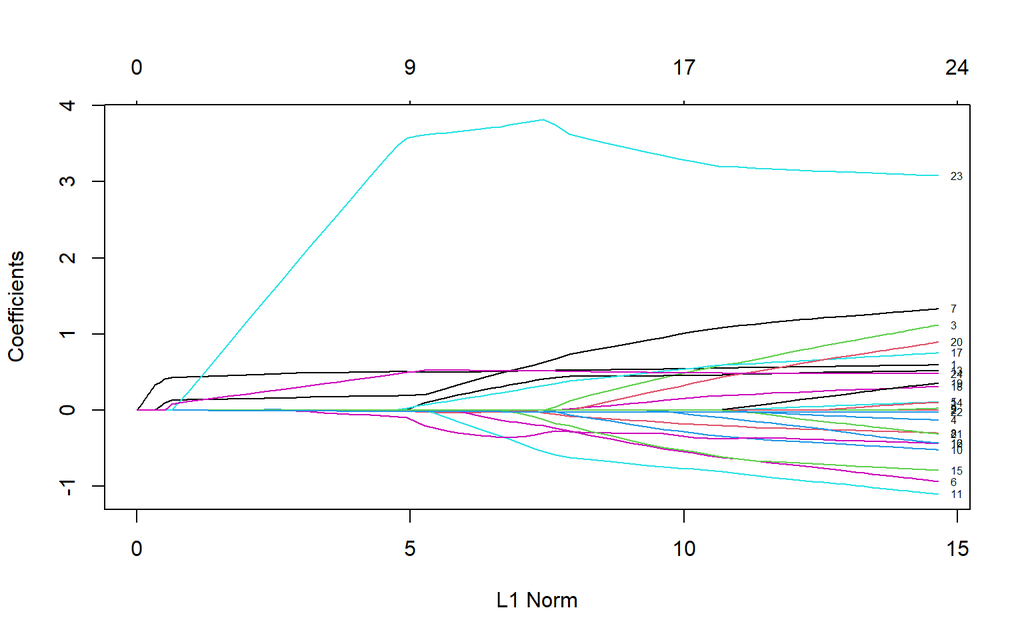

```r
plot(pfit2, label = TRUE)
```

#### 4.6.0.2 Adjusted Cross-Validated Logistic Regression Model Coefficient Plot

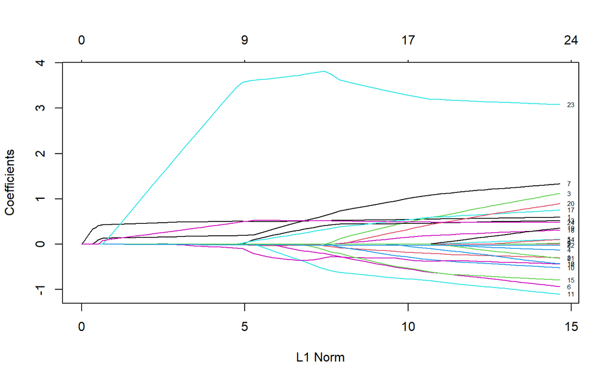

```r
#fit the cross-validatedmodel
cvfit2 <- cv.glmnet(x2, y2, family = "binomial")

plot(pfit2, label = TRUE)
```

## 4.7 - minimal lambda value

#### 4.7.0.1 Adjusted Cross-Validated Logistic Regressionn Coefficients using minimal lambda value

```r
#get the minimal lambda value (value of lambda that gives minimum cvm)
cvfit2$lambda.min
```

```
#> [1] 0.004815906
```

```r
# Cross-validated Logistic Regression Model using the minimal lambda
coef(cvfit2, s = "lambda.min")
```

```
#> 25 x 1 sparse Matrix of class "dgCMatrix"
#>                            s1
#> (Intercept)       -7.63441152
#> KIM1.npx           0.51316734
#> SYND1.npx         -0.01919300
#> IL.1RT1.npx        .
#> WFDC2.npx          .
#> CD27.npx           .
#> TNFRSF10A.npx     -0.14571047
#> LAYN.npx           0.51789884
#> PVRL4.npx          .
#> EDA2R.npx          .
#> TNFRSF4.npx        .
#> GFR_alpha_1_npx   -0.37556604
#> TNF.R1.npx        -0.35532940
#> PI3_npx            0.33088683
#> EFNA4.npx          .
#> TNF.R2.npx        -0.01614368
#> DLL1.npx           .
#> TNFRSF6B.npx       0.24583841
#> CD160.npx          .
#> EPHA2.npx          .
#> RELT.npx           .
#> LTBR.npx           .
#> BL_eGFR           -0.02058520
#> log10_B_HBA1C_PRC  3.74477373
#> log10_DU_ACR       0.51908922
```

## 4.8 - lambda.lse

#### 4.8.0.1 Adjusted Cross-Validated Logistic Regression Coefficients using lambda.lse

```r
#largest value of lambda such that error is within 1 standard error of the minimum.
cvfit2$lambda.lse
```

[output not shown]

```r
# Cross-validated Logistic Regression Model using the lambda.lse
coef(cvfit2)
```

```
#> 25 x 1 sparse Matrix of class "dgCMatrix"
#>                             s1
#> (Intercept)       -6.578259491
#> KIM1.npx           0.475366311
#> SYND1.npx          .
#> IL.1RT1.npx        .
#> WFDC2.npx          0.006548180
#> CD27.npx           .
#> TNFRSF10A.npx      .
#> LAYN.npx           0.158160908
#> PVRL4.npx          .
#> EDA2R.npx          .
#> TNFRSF4.npx        .
#> GFR_alpha_1_npx    .
#> TNF.R1.npx         .
#> PI3_npx            .
#> EFNA4.npx          .
#> TNF.R2.npx         .
#> DLL1.npx           .
#> TNFRSF6B.npx       .
#> CD160.npx          .
#> EPHA2.npx          .
#> RELT.npx           .
#> LTBR.npx           .
#> BL_eGFR           -0.005847513
#> log10_B_HBA1C_PRC  1.433519032
#> log10_DU_ACR       0.244912879
```